# Proyecto Final

# Informática en Ecología

#### Video de la presentación: https://1drv.ms/v/c/f329cf7e580031f4/EYjY2bykLo9NjBuBSANKnI4BqPFf4UiZo8690Wj9WkI8Wg?e=Mb2ZBa

### Profesores: Aline Pingarroni Martín del Campo y Daniel Martín Auliz Ortiz

### Equipo 1: Andrea Hermenegildo González y David Fidel Rojas Aguilar

## Análisis multivariado de los patrones de contaminación atmosférica en las 32 entidades federativas de la República Mexicana y la determinación de la emisión de contaminantes atmosféricos por tipo de fuente

[figure not shown]

### Base de datos 1: “Inventario de emisiones de contaminantes atmosféricos por municipio y fuente, 2018”

### Fuente: Plataforma Nacional de Datos Abiertos. (SEMARNAT, 2018). https://datos.gob.mx/dataset/calidad_aire_emisiones_contaminantes/resource/70dfeb69-065b-4ed4-8922-505602666250

### Base de datos 2: “Población total, indicadores socioeconómicos, índice y grado de marginación por municipio”

### Fuente: Plataforma Nacional de Datos Abiertos. (INEGI). https://datos.gob.mx/dataset/indices_marginacion/resource/d217f9aa-70e5-4176-b00b-3a92b7541a1e

## Marco Teórico:

### El Inventario Nacional de Emisiones de México (INEM) permite identificar las principales fuentes de emisión para establecer y proyectar las emisiones de México, utilizando herramientas que calculan las emisiones de contaminantes de diversas fuentes en una región específica, a nivel municipal o estatal, durante un año en concreto, conocido como año base.

### Estos inventarios ayudan a identificar las principales fuentes de contaminación, medir las emisiones y evaluar su impacto en la salud pública y el medio ambiente. Esta información permite a las autoridades y organizaciones diseñar estrategias efectivas para reducir las emisiones y cumplir con las normativas ambientales, además, los inventarios de emisiones son esenciales para la investigación científica y el desarrollo de tecnologías más limpias y eficientes.

## Tipos de Fuentes

### 1. Fuentes fijas:

### Instalaciones de ubicación fija que tienen como finalidad desarrollar operaciones o procesos industriales de manufactura

### 2. Fuentes móviles que circulan por carretera:

### Vehículos con motores de combustión y similares que abarca una variedad de vehículos como: tractocamiones, autobuses, camiones, automóviles, motocicletas

### 3. Fuentes móviles que no circulan por carretera:

### Vehículos con motores de combustión y similares, comprenden: aviones, helicópteros, ferrocarriles, tranvías, embarcaciones, equipo y maquinarias.

### 4. Fuentes de área:

### Fuentes pequeñas, numerosas y dispersas; abarca los comercios, servicios, viviendas, entre otros establecimientos.

### 5. Fuentes naturales:

### Emisiones biogénicas, las emisiones del suelo y la erosión eólica

## Contaminantes medidos:

### 1. Dióxido de azufre (SO2)

### 2. Monóxido de carbono(CO)

### 3. Óxidos de nitrógeno (NOx)

### 4. Compuestos Orgánicos Volátiles(COV)

### 5. Partículas igual o menores a 10 micrómetros (PM10)

### 6. Partículas igual o menores a 2.5 micrómetros (PM2.5)

### 7. Amoniaco (NH3)

## ¿Qué tipos de fuentes contribuyeron más a la emisión de cada tipo de contaminate? y ¿Cómo se agrupan los estados de México según su perfil de emisiones de distintos contaminantes, y qué contaminantes explican esas diferencias?

## 1. Cargar librerías necesarias

```r
#install.packages("tidyverse")
library(tidyverse) #procesamiento de datos
#install.packages("readxl")
library(readxl)
#install.packages("ggplot2")
library(ggplot2)
#install.packages("dplyr")
library(dplyr)
#install.packages("ggridges")
library(ggridges)
#install.packages("tidyr")
library(tidyr)
#install.packages("writexl")
library(writexl)
#install.packages("rgbif")
library(rgbif) #descargar datos de ocurrencias
#install.packages("sf")
library(sf) #manipulaci?n  de datos vectoriales
#install.packages("rworldxtra")
library(rworldxtra) #datos vectoriales de los paises del mundo
#install.packages("geodata")
library(geodata) #datos geoespaciales complemenatarios
#install.packages("ggspatial")
library(ggspatial)#auxiliar para visualizar datos espaciales
#install.packages("terra")
library(terra) #datos raster
#install.packages("tidyterra")
library(tidyterra) #maniipulaci?n de raster
#install.packages("paletteer")
library(paletteer) #colores
#install.packages("ggcorrplot")
library(ggcorrplot) #diagrama de correlaciones
#install.packages("plotly")
library(plotly) #gr?ficos avanzados
#install.packages("patchwork")
library(patchwork) #organizar gr?ficos
#install.packages("magick")
library(magick) #para manejo de imagenes
#install.packages("grid")
library(grid)
#install.packages("factoextra")
library(factoextra)
#install.packages("ggfortify")
library(ggfortify)
```

## 2. Importación y modificación de base de datos

### 2.1 Población

```r
#Guarda en pt la 2° hoja de la base original pues esta contiene las mediciones.
pt <- read_excel("IMM_2020.xlsx", sheet = 2)

#Toda la información del último censo en 2020
head(pt)
```

```
## # A tibble: 6 × 17
##   CVE_ENT NOM_ENT    CVE_MUN NOM_MUN POB_TOT ANALF SBASC OVSDE OVSEE OVSAE  OVPT
##   <chr>   <chr>      <chr>   <chr>     <dbl> <dbl> <dbl> <dbl> <dbl> <dbl> <dbl>
## 1 01      Aguascali… 01001   Aguasc…  948990  1.64  20.4 0.105 0.113 0.379 0.591
## 2 01      Aguascali… 01002   Asient…   51536  3.53  33.9 2.65  0.486 0.858 1.35
## 3 01      Aguascali… 01003   Calvil…   58250  4.49  42.5 0.365 0.517 0.801 1.04
## 4 01      Aguascali… 01004   Cosío     17000  3.14  27.7 0.713 0.577 0.660 1.03
## 5 01      Aguascali… 01005   Jesús …  129929  2.38  26.7 0.277 0.355 0.860 1.31
## 6 01      Aguascali… 01006   Pabell…   47646  2.73  25.7 0.541 0.425 1.04  0.706
## # ℹ 6 more variables: VHAC <dbl>, PL.5000 <dbl>, PO2SM <dbl>, IM_2020 <dbl>,
## #   GM_2020 <chr>, IMN_2020 <dbl>
```

```r
pob <- pt %>%
  group_by(NOM_ENT) %>% #agrupa por estados
  summarize(Poblacion_total = sum(POB_TOT, na.rm = TRUE)
   #suma las poblaciones de cada municipio, guardandolo el Poblacion_total, y esto lo tendrá en una fila por estado
            )
#pob es la tabla de estados de México y la poblacipon regsitrada en el año 2020
head(pob)
```

```
## # A tibble: 6 × 2
##   NOM_ENT             Poblacion_total
##   <chr>                         <dbl>
## 1 Aguascalientes              1425607
## 2 Baja California             3769020
## 3 Baja California Sur          798447
## 4 Campeche                     928363
## 5 Chiapas                     5543828
## 6 Chihuahua                   3741869
```

### 2.2 Área de estados

```r
#Guardamos el archivo de las entidades de tipo shp
mexshp <- st_read("entidades_mex.shp")
#Guardamos en estados como dataframe
estados <- as.data.frame(mexshp)
```

### 2.3 Combinación de población y geografía de cada estado

```r
#Qué nombres maneja estados y pob
unique(estados$NOMGEO)
```

```
##  [1] "Aguascalientes"       "Baja California"      "Baja California Sur"
##  [4] "Campeche"             "Coahuila de Zaragoza" "Colima"
##  [7] "Chiapas"              "Chihuahua"            "Ciudad de México"
## [10] "Durango"              "Guanajuato"           "Guerrero"
## [13] "Hidalgo"              "Jalisco"              "Estado de México"
## [16] "Michoacán"            "Morelos"              "Nayarit"
## [19] "Nuevo León"           "Oaxaca"               "Puebla"
## [22] "Querétaro"            "Quintana Roo"         "San Luis Potosí"
## [25] "Sinaloa"              "Sonora"               "Tabasco"
## [28] "Tamaulipas"           "Tlaxcala"             "Veracruz"
## [31] "Yucatán"              "Zacatecas"
```

```r
unique(pob$NOM_ENT)
```

```
##  [1] "Aguascalientes"                  "Baja California"
##  [3] "Baja California Sur"             "Campeche"
##  [5] "Chiapas"                         "Chihuahua"
##  [7] "Ciudad de México"                "Coahuila de Zaragoza"
##  [9] "Colima"                          "Durango"
## [11] "Guanajuato"                      "Guerrero"
## [13] "Hidalgo"                         "Jalisco"
## [15] "Michoacán de Ocampo"             "Morelos"
## [17] "México"                          "Nayarit"
## [19] "Nuevo León"                      "Oaxaca"
## [21] "Puebla"                          "Querétaro"
## [23] "Quintana Roo"                    "San Luis Potosí"
## [25] "Sinaloa"                         "Sonora"
## [27] "Tabasco"                         "Tamaulipas"
## [29] "Tlaxcala"                        "Veracruz de Ignacio de la Llave"
## [31] "Yucatán"                         "Zacatecas"
```

```r
#Estado, Michoacán y Veracruz no coinciden

#Modificamos los nombres de pob para que coincidan en la unión
pob <- pob %>%
  #Dentro de pob...
  mutate( #...modifica las colmunas.
    NOM_ENT = case_when( #En específico a esta <<En caso de...>>
      NOM_ENT== "México" ~ "Estado de México",
      NOM_ENT == "Michoacán de Ocampo" ~ "Michoacán",
      NOM_ENT == "Veracruz de Ignacio de la Llave" ~ "Veracruz",
      TRUE ~ NOM_ENT
    ))

#union
union0 <- left_join(estados,pob, by = c ("NOMGEO" = "NOM_ENT"))

#union0 tiene tanto la información geográfica de cada estado como su población
head(union0)
```

```
##   CVEGEO CVE_ENT               NOMGEO    area_ha                       geometry
## 1     01      01       Aguascalientes   555867.4 MULTIPOLYGON (((-102.2879 2...
## 2     02      02      Baja California  7351669.7 MULTIPOLYGON (((-112.3007 2...
## 3     03      03  Baja California Sur  7397068.7 MULTIPOLYGON (((-109.8945 2...
## 4     04      04             Campeche  5725451.2 MULTIPOLYGON (((-91.9565 20...
## 5     05      05 Coahuila de Zaragoza 15067122.3 MULTIPOLYGON (((-102.3108 2...
## 6     06      06               Colima   575325.7 MULTIPOLYGON (((-114.7373 1...
##   Poblacion_total
## 1         1425607
## 2         3769020
## 3          798447
## 4          928363
## 5         3146771
## 6          731391
```

### 2.4 Tabla demográfica

```r
#demo tendrá sólo los estados, su área y poblacipon total
demo <- union0 %>%
  select(NOMGEO,area_ha,Poblacion_total)

#Se crea una nuevacolumna de km2
demo <- demo %>%
  mutate(km2 = area_ha/100)

#para poder tener la densidad: población/km2 de cada estado.
demo <- demo %>%
  mutate(densidad = Poblacion_total/km2)

#qué variables hay en demo
names(demo)
```

```
## [1] "NOMGEO"          "area_ha"         "Poblacion_total" "km2"
## [5] "densidad"
```

### 2.5 Mapa de México y densidad de población por estado

```r
#Verificamos los nombres de los estados en ambas bases
unique(mexshp$NOMGEO)
```

```
##  [1] "Aguascalientes"       "Baja California"      "Baja California Sur"
##  [4] "Campeche"             "Coahuila de Zaragoza" "Colima"
##  [7] "Chiapas"              "Chihuahua"            "Ciudad de México"
## [10] "Durango"              "Guanajuato"           "Guerrero"
## [13] "Hidalgo"              "Jalisco"              "Estado de México"
## [16] "Michoacán"            "Morelos"              "Nayarit"
## [19] "Nuevo León"           "Oaxaca"               "Puebla"
## [22] "Querétaro"            "Quintana Roo"         "San Luis Potosí"
## [25] "Sinaloa"              "Sonora"               "Tabasco"
## [28] "Tamaulipas"           "Tlaxcala"             "Veracruz"
## [31] "Yucatán"              "Zacatecas"
```

```r
unique(demo$NOMGEO)
```

```
##  [1] "Aguascalientes"       "Baja California"      "Baja California Sur"
##  [4] "Campeche"             "Coahuila de Zaragoza" "Colima"
##  [7] "Chiapas"              "Chihuahua"            "Ciudad de México"
## [10] "Durango"              "Guanajuato"           "Guerrero"
## [13] "Hidalgo"              "Jalisco"              "Estado de México"
## [16] "Michoacán"            "Morelos"              "Nayarit"
## [19] "Nuevo León"           "Oaxaca"               "Puebla"
## [22] "Querétaro"            "Quintana Roo"         "San Luis Potosí"
## [25] "Sinaloa"              "Sonora"               "Tabasco"
## [28] "Tamaulipas"           "Tlaxcala"             "Veracruz"
## [31] "Yucatán"              "Zacatecas"
```

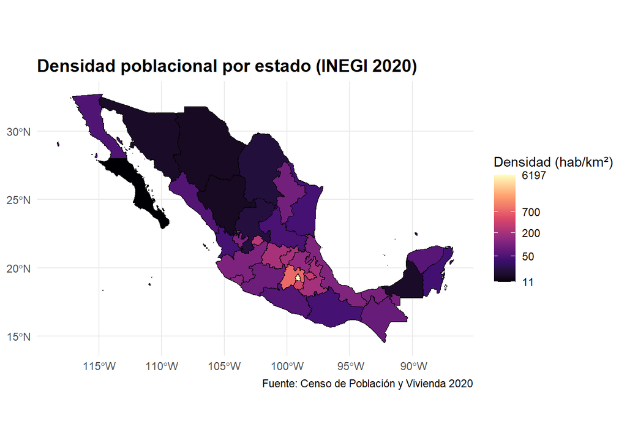

```r
#Todos coinciden

#Combina las tablas geográfica y demográfica
mexdens <- mexshp %>%
  left_join(demo, by = "NOMGEO")

#Grafica el mapa
ggplot(mexdens) +
  geom_sf(aes(fill = densidad), color = "black", size = 0.2) +
  scale_fill_viridis_c(
    option = "magma",
    trans = "log",                 # 🔹 transformación logarítmica
    name = "Densidad (hab/km²)",
    breaks = c(11, 50, 200, 700, 6197), # 🔹 puedes ajustar según tus datos
    labels = c("11", "50","200", "700", "6197")
  ) +
  theme_minimal() +
  labs(title = "Densidad poblacional por estado (INEGI 2020)",
       caption = "Fuente: Censo de Población y Vivienda 2020") +
  theme(plot.title = element_text(face = "bold", size = 14),
        legend.position = "right")
```

### 2.6 Contaminación

### 2.6.1 Contaminación por estado

```r
######Contaminantes por estado######
#Se guarda en cm la información que existe en la tabla de mediciones promedio del año de contaminantes por municipio tomado en el año 2018
cm <- read_csv("contaminantes.csv")

#co es la tabla de los estados de México y la cantidad promedio de 7 contaminantes en el año 2018
co <- cm %>%
  #Dentro de cm...
  group_by(Entidad_federativa) %>%
  #Agrupa por entidades y...
  summarize(across(3:9, ~ mean(.x, na.rm = TRUE)
  #De las columnas de contaminantes (3:9), crea el promedio de todas las cantidades registras, creando una solo fila para cada estado
  ))

#Vemos las variables y tipos de datos de co, las emisiones promedio de cada contaminante por estado
head(co)
```

```
## # A tibble: 6 × 8
##   Entidad_federativa    SO_2     CO   NOx   COV PM_010 PM_2_5  NH_3
##   <chr>                <dbl>  <dbl> <dbl> <dbl>  <dbl>  <dbl> <dbl>
## 1 Aguascalientes        92.8  1771.  448.  890.  140.    74.2 1140.
## 2 Baja California      161.  10158. 2279. 3303.  978.   510.   399.
## 3 Baja California Sur 1910.   4736. 2098.  893.  387.   145.   101.
## 4 Campeche            2693.   2949.  728. 1329.  413.   312.   201.
## 5 Chiapas               35.2   931.  304. 2609.   91.9   73.5  126.
## 6 Chihuahua             78.4  2260.  339.  496.  195.   132.   115.
```

### 2.6.2 Contaminantes por tipo de fuente por estado

```r
#cpf tiene el promedio de 7 contaminantes por por tipo de fuente de cada estado de Méxic
cpf <- cm %>%
  #Dentro de cm...
  group_by(Entidad_federativa, Tipo_de_Fuente) %>%
  #... agrupa por Entidad_federativa y Tipo de Fuente, luego...
  summarise(across(2:8, ~ mean(.x, na.rm = TRUE)))
#De las columnas 2:8 (contaminantes) saca su promedio y colocalos en filas separadas

head(cpf)
```

```
## # A tibble: 6 × 9
## # Groups:   Entidad_federativa [2]
##   Entidad_federativa Tipo_de_Fuente     SO_2     CO    NOx    COV  PM_010 PM_2_5
##   <chr>              <chr>             <dbl>  <dbl>  <dbl>  <dbl>   <dbl>  <dbl>
## 1 Aguascalientes     Fuentes de área    3.33  570.    55.2 1.67e3  320.   116.
## 2 Aguascalientes     Fuentes fijas    414.    241.   357.  3.17e2  147.   102.
## 3 Aguascalientes     Fuentes móviles…  36.4  5786.  1235.  6.11e2   84.2   77.0
## 4 Aguascalientes     Fuentes móviles…   5.01   70.1  159.  1.35e1    9.73   9.36
## 5 Aguascalientes     Fuentes natural… NaN     NaN    407.  1.69e3  NaN    NaN
## 6 Baja California    Fuentes de área   43.4  5752.   368.  1.11e4 2277.   874.
## # ℹ 1 more variable: NH_3 <dbl>
```

```r
#cpf tiene el promedio de 7 contaminantes por por tipo de fuente de cada estado de México
```

### 2.7 Mapas de México y contaminantes por estado

### 2.7.1 Ajuste de bases de datos

```r
#Verificamos que ambas bases manejen los mismos nombres por entidad
unique(co$Entidad_federativa)
```

```
##  [1] "Aguascalientes"      "Baja California"     "Baja California Sur"
##  [4] "Campeche"            "Chiapas"             "Chihuahua"
##  [7] "Ciudad de México"    "Coahuila"            "Colima"
## [10] "Durango"             "Guanajuato"          "Guerrero"
## [13] "Hidalgo"             "Jalisco"             "Michoacán"
## [16] "Morelos"             "México"              "Nayarit"
## [19] "Nuevo León"          "Oaxaca"              "Puebla"
## [22] "Querétaro"           "Quintana Roo"        "San Luis Potosí"
## [25] "Sinaloa"             "Sonora"              "Tabasco"
## [28] "Tamaulipas"          "Tlaxcala"            "Veracruz"
## [31] "Yucatán"             "Zacatecas"
```

```r
unique(mexshp$NOMGEO)
```

```
##  [1] "Aguascalientes"       "Baja California"      "Baja California Sur"
##  [4] "Campeche"             "Coahuila de Zaragoza" "Colima"
##  [7] "Chiapas"              "Chihuahua"            "Ciudad de México"
## [10] "Durango"              "Guanajuato"           "Guerrero"
## [13] "Hidalgo"              "Jalisco"              "Estado de México"
## [16] "Michoacán"            "Morelos"              "Nayarit"
## [19] "Nuevo León"           "Oaxaca"               "Puebla"
## [22] "Querétaro"            "Quintana Roo"         "San Luis Potosí"
## [25] "Sinaloa"              "Sonora"               "Tabasco"
## [28] "Tamaulipas"           "Tlaxcala"             "Veracruz"
## [31] "Yucatán"              "Zacatecas"
```

```r
#Coahuila y Edomex no coinciden

#Modificamos
mexshp <- mexshp %>%
  #Dentro de pob...
  mutate( #...modifica las colmunas.
    NOMGEO = case_when( #En específico a esta <<En caso de...>>
      NOMGEO == "Estado de México" ~ "México",
      NOMGEO  == "Coahuila de Zaragoza" ~ "Coahuila",
      TRUE ~ NOMGEO
    ))

#Creamos una nueva tabla que comnbina los datos de emisiones con la geografía
mexco <- mexshp %>%
  left_join(co, by = c("NOMGEO" ="Entidad_federativa"))
```

### 2.7.2 Mapas por contamiante

### Dióxido de Azufre

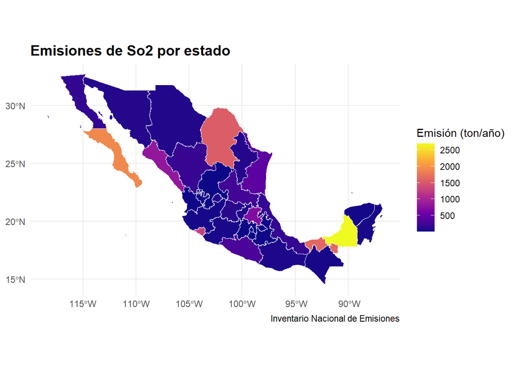

```r
ggplot(mexco) +
  geom_sf(aes(fill = SO_2 ), color = "white", size = 0.2) +
  scale_fill_viridis_c(option = "plasma", name = "Emisión (ton/año)") +
  theme_minimal() +
  labs(title = "Emisiones de So2 por estado",
       caption = "Inventario Nacional de Emisiones") +
  theme(plot.title = element_text(face = "bold", size = 14))
```

### Monóxido de carbono

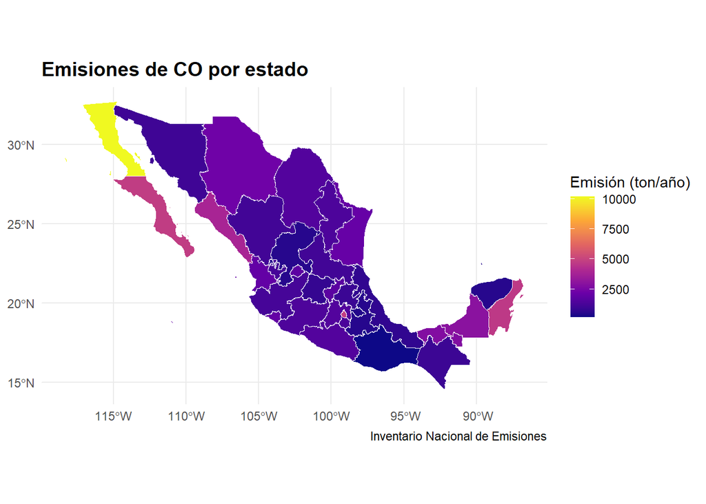

```r
ggplot(mexco) +
  geom_sf(aes(fill = CO ), color = "white", size = 0.2) +
  scale_fill_viridis_c(option = "plasma", name = "Emisión (ton/año)") +
  theme_minimal() +
  labs(title = "Emisiones de CO por estado",
       caption = "Inventario Nacional de Emisiones") +
  theme(plot.title = element_text(face = "bold", size = 14))
```

### Óxidos de Nitrogeno

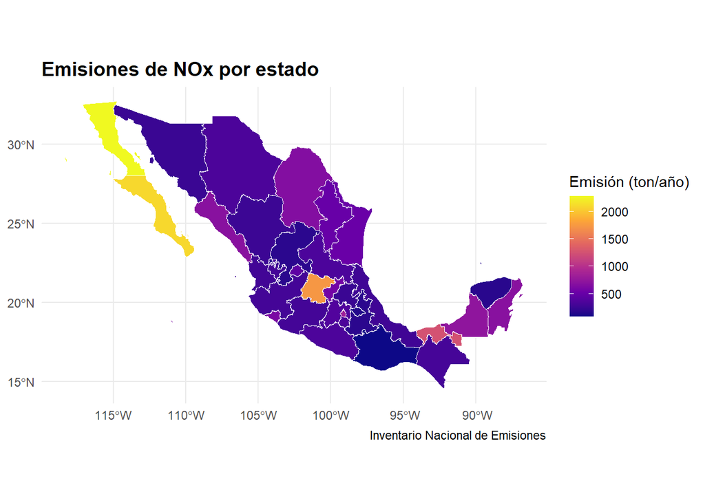

```r
ggplot(mexco) +
  geom_sf(aes(fill = NOx ), color = "white", size = 0.2) +
  scale_fill_viridis_c(option = "plasma", name = "Emisión (ton/año)") +
  theme_minimal() +
  labs(title = "Emisiones de NOx por estado",
       caption = "Inventario Nacional de Emisiones") +
  theme(plot.title = element_text(face = "bold", size = 14))
```

### Compuestos orgáinicos volátiles

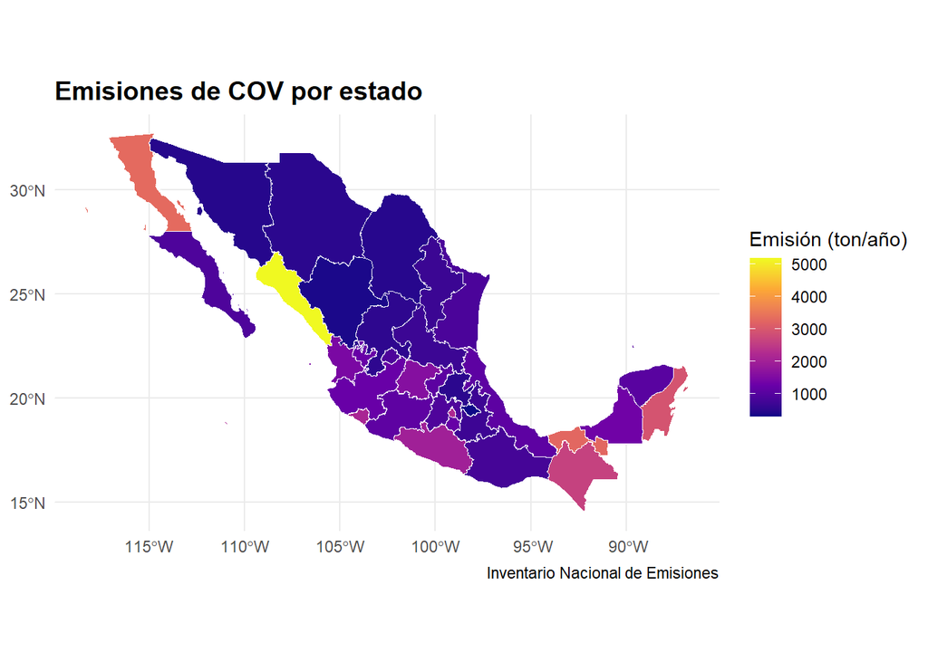

```r
ggplot(mexco) +
  geom_sf(aes(fill = COV ), color = "white", size = 0.2) +
  scale_fill_viridis_c(option = "plasma", name = "Emisión (ton/año)") +
  theme_minimal() +
  labs(title = "Emisiones de COV por estado",
       caption = "Inventario Nacional de Emisiones") +
  theme(plot.title = element_text(face = "bold", size = 14))
```

### Particulas menores o iguales a 10 micras

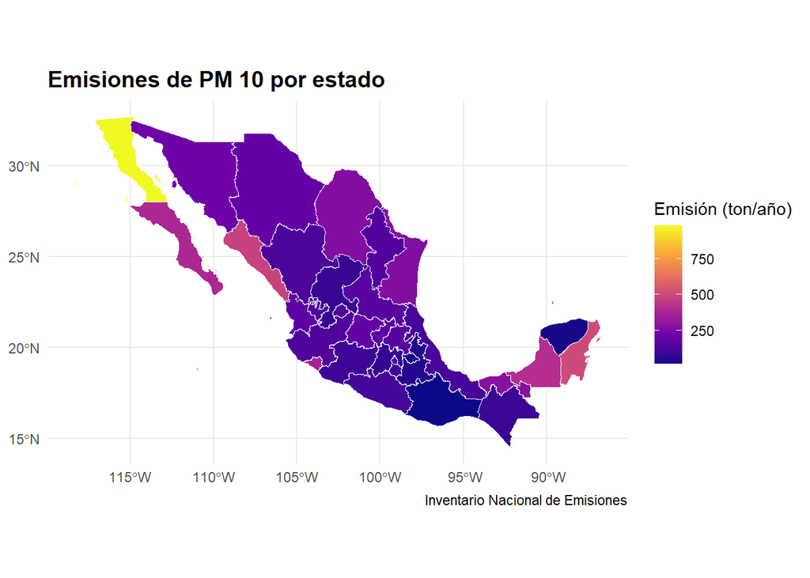

```r
ggplot(mexco) +
  geom_sf(aes(fill = PM_010 ), color = "white", size = 0.2) +
  scale_fill_viridis_c(option = "plasma", name = "Emisión (ton/año)") +
  theme_minimal() +
  labs(title = "Emisiones de PM 10 por estado",
       caption = "Inventario Nacional de Emisiones") +
  theme(plot.title = element_text(face = "bold", size = 14))
```

### Particulas menores o iguales a 2.5 micras

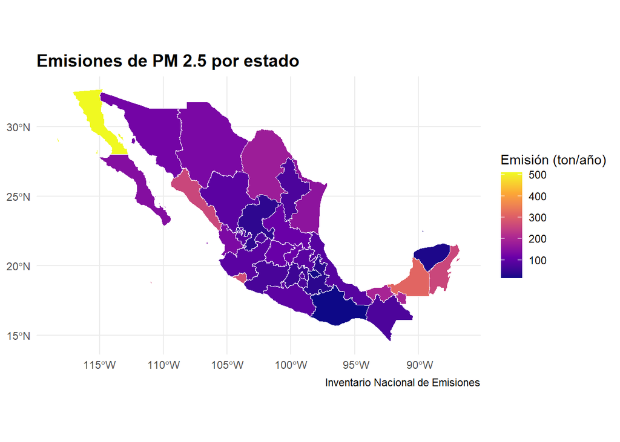

```r
ggplot(mexco) +
  geom_sf(aes(fill = PM_2_5 ), color = "white", size = 0.2) +
  scale_fill_viridis_c(option = "plasma", name = "Emisión (ton/año)") +
  theme_minimal() +
  labs(title = "Emisiones de PM 2.5 por estado",
       caption = "Inventario Nacional de Emisiones") +
  theme(plot.title = element_text(face = "bold", size = 14))
```

### Amoniaco

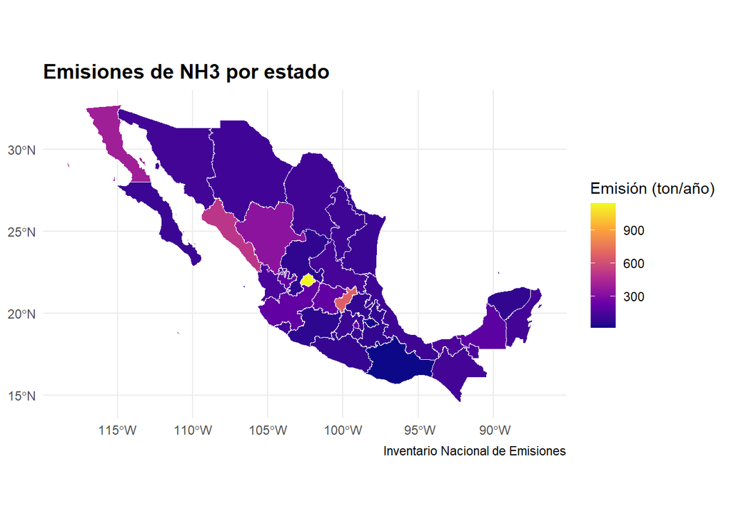

```r
ggplot(mexco) +
  geom_sf(aes(fill = NH_3 ), color = "white", size = 0.2) +
  scale_fill_viridis_c(option = "plasma", name = "Emisión (ton/año)") +
  theme_minimal() +
  labs(title = "Emisiones de NH3 por estado",
       caption = "Inventario Nacional de Emisiones") +
  theme(plot.title = element_text(face = "bold", size = 14))
```

## 3. Análisis

### 3.1 Uniones finales para los análisis

```r
##Cambio de nombre de estados##

#Se verifica los nombres de los estados que maneja cada base
unique(demo$NOMGEO)
```

```
##  [1] "Aguascalientes"       "Baja California"      "Baja California Sur"
##  [4] "Campeche"             "Coahuila de Zaragoza" "Colima"
##  [7] "Chiapas"              "Chihuahua"            "Ciudad de México"
## [10] "Durango"              "Guanajuato"           "Guerrero"
## [13] "Hidalgo"              "Jalisco"              "Estado de México"
## [16] "Michoacán"            "Morelos"              "Nayarit"
## [19] "Nuevo León"           "Oaxaca"               "Puebla"
## [22] "Querétaro"            "Quintana Roo"         "San Luis Potosí"
## [25] "Sinaloa"              "Sonora"               "Tabasco"
## [28] "Tamaulipas"           "Tlaxcala"             "Veracruz"
## [31] "Yucatán"              "Zacatecas"
```

```r
unique(co$Entidad_federativa)
```

```
##  [1] "Aguascalientes"      "Baja California"     "Baja California Sur"
##  [4] "Campeche"            "Chiapas"             "Chihuahua"
##  [7] "Ciudad de México"    "Coahuila"            "Colima"
## [10] "Durango"             "Guanajuato"          "Guerrero"
## [13] "Hidalgo"             "Jalisco"             "Michoacán"
## [16] "Morelos"             "México"              "Nayarit"
## [19] "Nuevo León"          "Oaxaca"              "Puebla"
## [22] "Querétaro"           "Quintana Roo"        "San Luis Potosí"
## [25] "Sinaloa"             "Sonora"              "Tabasco"
## [28] "Tamaulipas"          "Tlaxcala"            "Veracruz"
## [31] "Yucatán"             "Zacatecas"
```

```r
unique(cpf$Entidad_federativa)
```

```
##  [1] "Aguascalientes"      "Baja California"     "Baja California Sur"
##  [4] "Campeche"            "Chiapas"             "Chihuahua"
##  [7] "Ciudad de México"    "Coahuila"            "Colima"
## [10] "Durango"             "Guanajuato"          "Guerrero"
## [13] "Hidalgo"             "Jalisco"             "Michoacán"
## [16] "Morelos"             "México"              "Nayarit"
## [19] "Nuevo León"          "Oaxaca"              "Puebla"
## [22] "Querétaro"           "Quintana Roo"        "San Luis Potosí"
## [25] "Sinaloa"             "Sonora"              "Tabasco"
## [28] "Tamaulipas"          "Tlaxcala"            "Veracruz"
## [31] "Yucatán"             "Zacatecas"
```

```r
demo <- demo %>%
  #Dentro de pob...
  mutate( #...modifica las colmunas.
    NOMGEO = case_when( #En específico a esta <<En caso de...>>
      NOMGEO == "Estado de México" ~ "México",
      NOMGEO  == "Coahuila de Zaragoza" ~ "Coahuila",
      TRUE ~ NOMGEO
    ))

#Se verifica si han sido cambiadas
unique(demo$NOMGEO)
```

```
##  [1] "Aguascalientes"      "Baja California"     "Baja California Sur"
##  [4] "Campeche"            "Coahuila"            "Colima"
##  [7] "Chiapas"             "Chihuahua"           "Ciudad de México"
## [10] "Durango"             "Guanajuato"          "Guerrero"
## [13] "Hidalgo"             "Jalisco"             "México"
## [16] "Michoacán"           "Morelos"             "Nayarit"
## [19] "Nuevo León"          "Oaxaca"              "Puebla"
## [22] "Querétaro"           "Quintana Roo"        "San Luis Potosí"
## [25] "Sinaloa"             "Sonora"              "Tabasco"
## [28] "Tamaulipas"          "Tlaxcala"            "Veracruz"
## [31] "Yucatán"             "Zacatecas"
```

```r
###Uniones de tablas##

#union1 es la tabla que contiene a las entidades federativaS, el promedio de emisiones por contaminante más la poblacipon y densidad por estado.
union1 <- left_join(co,demo, by = c ("Entidad_federativa" = "NOMGEO"))

head(union1)
```

```
## # A tibble: 6 × 12
##   Entidad_federativa    SO_2     CO   NOx   COV PM_010 PM_2_5  NH_3   area_ha
##   <chr>                <dbl>  <dbl> <dbl> <dbl>  <dbl>  <dbl> <dbl>     <dbl>
## 1 Aguascalientes        92.8  1771.  448.  890.  140.    74.2 1140.   555867.
## 2 Baja California      161.  10158. 2279. 3303.  978.   510.   399.  7351670.
## 3 Baja California Sur 1910.   4736. 2098.  893.  387.   145.   101.  7397069.
## 4 Campeche            2693.   2949.  728. 1329.  413.   312.   201.  5725451.
## 5 Chiapas               35.2   931.  304. 2609.   91.9   73.5  126.  7361195.
## 6 Chihuahua             78.4  2260.  339.  496.  195.   132.   115. 24697336.
## # ℹ 3 more variables: Poblacion_total <dbl>, km2 <dbl>, densidad <dbl>
```

```r
#union2 tiene la cantidad promedio de 7 contaminantes por su tipo de fuente de cada entidad federativa, más la población y densidad  de cada estado.
union2 <- left_join(cpf,demo, by = c ("Entidad_federativa" = "NOMGEO"))

head(union2)
```

```
## # A tibble: 6 × 13
## # Groups:   Entidad_federativa [2]
##   Entidad_federativa Tipo_de_Fuente     SO_2     CO    NOx    COV  PM_010 PM_2_5
##   <chr>              <chr>             <dbl>  <dbl>  <dbl>  <dbl>   <dbl>  <dbl>
## 1 Aguascalientes     Fuentes de área    3.33  570.    55.2 1.67e3  320.   116.
## 2 Aguascalientes     Fuentes fijas    414.    241.   357.  3.17e2  147.   102.
## 3 Aguascalientes     Fuentes móviles…  36.4  5786.  1235.  6.11e2   84.2   77.0
## 4 Aguascalientes     Fuentes móviles…   5.01   70.1  159.  1.35e1    9.73   9.36
## 5 Aguascalientes     Fuentes natural… NaN     NaN    407.  1.69e3  NaN    NaN
## 6 Baja California    Fuentes de área   43.4  5752.   368.  1.11e4 2277.   874.
## # ℹ 5 more variables: NH_3 <dbl>, area_ha <dbl>, Poblacion_total <dbl>,
## #   km2 <dbl>, densidad <dbl>
```